# UPHL Reporting Limits: 2017

T.Hooker

4 December, 2017

```r
#packge.set <- c("knitr", "rmarkdown", "plyr", "openxlsx", "lubridate", "htmlTable",
#                "reshape2", "tidyr", "formatR", "xtable", "dplyr")
#lapply(packge.set, library, character.only=T)
#options(table_counter=FALSE)
options(scipen = 999, digits = 4)
#opts_chunk$set(tidy=TRUE)
##
#startwork.date <- format(Sys.Date(), "%y%m%d")
```

### Notes

This project summarizes Blank and Reporting Limit information from UPHL-EDDs (more recent) and/or AWQMS recrods for data-users who work with temporal trends.

This project extracts the working Geofile from AWQMS, then pulls in data from UPHL-EDDs (current) and/or from AWQMS (older, imported data; not pursued at present time) for **Sample-Blanks** te be evaluated.

### 1.0 Import Geofile

#### 1.1 AWQMS Export

1. Log in to AWQMS
2. Select [Metadata]
3. Select [Search] to obtain the entire list of `Monitoring Location` records
4. Select [Export to Excel] to retrieve the xlsx file
5. *Save* to working space

#### 1.1 Import MLID info

```r
#geo.file <- choose.files(caption="Select xlsx File to Import", multi=FALSE)
MLID.file <- openxlsx::read.xlsx(geo.file, sheet=1, startRow = 1, colNames=TRUE, rowNames=FALSE, detectDates=TRUE);
path.geofile <- dirname(geo.file)
Geofile.name <- basename(geo.file)
```

**Geofile-dataset Info**::

- **Data File Name:** MonitoringLocationsExport_awqms_171204.xlsx
- **Data File Path:** L:/DATA MANAGEMENT & QA/Reporting Limits/UPHL_RLs_2017_r
- Imported datafile has **51** Columns and **7,829** records

#### 1.2 Cleanup

**Clean up Date Records**

```r
MLID.file$Last.Change <- openxlsx::convertToDateTime(MLID.file$Last.Change, origin="1899-12-30")
MLID.file$Created <- openxlsx::convertToDateTime(MLID.file$Created, origin="1899-12-30")
```

- `Date.Established` == OK
- `Last.Change` == OK
- `Created` == OK

#### 1.3 Extract QC-Blank Sites

Look in `Description` field for terms similar to “blank”

```r
Blank.MLID <- MLID.file[(grep("BLANK", toupper(MLID.file$Description))),]
```

- Total if 98 records contain the term “Blank” (capitalization insensitive) in the `Description` field
  - 98 unique MLIDs in file

### 2.0 Import UPHL-EDDs

#### 2.1 Import EDD file[s]

```r
#files <- choose.files(caption="Select DATA files [*.txt]", multi = TRUE)
#b <- lapply(files, FUN=read.delim, header=TRUE, as.is=TRUE)
filename <- basename(files)
names(b) <- filename
path.filename <- dirname(files)
```

```r
EDD.dat0 <- plyr::ldply(b, .id="Lab.filename")
```

- A total of 40 data files were selected from path:
  - **K:/WQX/processed**
- Total number of data-records from imported EDDs :: 81,146
  - Number of unique `Lab.filename` in data :: 40
  - Number of unique `MLID`s in data :: 586

#### 2.2 Cleanup [edd.data]

**Clean Dates**

```r
EDD.dat0$Sample.Date <- as.Date(lubridate::parse_date_time(EDD.dat0$Sample.Date, "mdy HMS", truncated=3))
EDD.dat0$Sample.Received.Date <- as.Date(lubridate::parse_date_time(EDD.dat0$Sample.Received.Date, "mdy HMS", truncated=3))
EDD.dat0$Analysis.Date <- as.Date(lubridate::parse_date_time(EDD.dat0$Analysis.Date, "mdy HMS", truncated=3))
```

#### 2.3 Parameter-Table [edd.data]

Obtain [*working*] **Master Parameter Table** (as .Rdata workspace element) from ::

- **PATH** :: “L:/DATA MANAGEMENT & QA/DATA.Projects/MASTER_PARAMETER_Tables_r”
- **File** :: “EDD.param2_170906.RData”
- **Data-Frame** :: `EDD.param2`

```r
#file.PARAM <- choose.files(caption="Select DATA files [*.RData]", multi = TRUE)
#load(file.PARAM)
# DataFrame is :: EDD.param2
# Master PARAM cleanup
EDD.param2$MethPar.key <- paste(trimws(EDD.param2$Method.ID), trimws(EDD.param2$Param.Description), sep=".")
EDD.param2$ParamX <- ifelse(!is.na(EDD.param2$PARAM.0), trimws(EDD.param2$PARAM.0),
                          ifelse(!is.na(EDD.param2$PARAM1), EDD.param2$PARAM1, "CHEK"))
#
EDD.param2 <- rbind(EDD.param2, EDD.param2[36,])
EDD.param2$Method.ID[106] <- "300.0" # fix of Method.ID format...
EDD.param2 <- EDD.param2[,c(1,ncol(EDD.param2), (ncol(EDD.param2)-1), 2:(ncol(EDD.param2)-2))]
#3 some manual cleanup (weird digits in some Method.IDs...)
#EDD.param2 <- EDD.param2[-c(EDD.param2$MethPar.key),]
```

- Parameter table (`EDD.param2`) contains 106 records, with
  - 15 duplicated levels of $MethPar.key
  - Duplicated MethPar.keys ::

```r
tab <- as.data.frame(table(EDD.param2$MethPar.key, useNA = "ifany"))
names(tab)[1] <- "MethPar.key"
tab <- dplyr::arrange(tab, desc(Freq))
tab <- tab[tab$Freq>1,]
htmlTable::htmlTable(tab, css.cell = rbind(rep("padding-left: 0.7em; padding-right: 0.9em;font-size: 0.8em;", times=ncol(tab)), matrix("padding-left: 0.8em; padding-right: 0.8em; font-size: 0.8em;",ncol=ncol(tab), nrow=nrow(tab))))
```

|  | MethPar.key | Freq |
| --- | --- | --- |
| 1 | 180.1.Turbidity | 2 |
| 2 | 200.8.Mn | 2 |
| 3 | 200.8.Ni | 2 |
| 4 | 200.8.Pb | 2 |
| 5 | 200.8.Se | 2 |
| 6 | 200.8.Zn | 2 |
| 7 | 300.Fluoride by IC | 2 |
| 8 | 335.4.Total Cyanide | 2 |
| 9 | 351.2.TKN as Nitrogen | 2 |
| 10 | 5210B.BOD | 2 |
| 11 | 9223-QT.Comment | 2 |
| 12 | 9223-QT.MPN E. Coli | 2 |
| 13 | 9223-QT.MPN Total Coliforms | 2 |
| 14 | 9223-QT.Multiplier | 2 |
| 15 | SM5210B.SCBOD | 2 |

- Some of the above *duplicated* Method-x-parameter keys may need to be cleaned up…

#### 2.4 Simplified Project Names

Import a summary of Project-IDs (w/ simplified names) based on TripIDs

```r
PROJ.file <- choose.files(caption="Select xlsx File to Import", multi=FALSE)
Projects <- openxlsx::read.xlsx(PROJ.file, sheet=1, startRow = 1, colNames=TRUE, rowNames=FALSE, detectDates=TRUE);
path.projects <- dirname(PROJ.file)
projects.name <- basename(PROJ.file)
# cleanup
Projects[is.na(Projects$TripID),3] <- "missing"
```

**Imported Project-ID file** :: UPHL_wy2017_Project-IDs_v01_171119.xlsx  
**Path to file** :: W:/2017_wy_Data/2017 Water Year_Lab Data/2017 UPHL LIMS/2017wy_uphl_set2_R  
**Data-frame** :: `Projects`

Current Project-ID summary contains:

- 315 records
- 53 simplified project names

*Script for simplifying TripIDs to Projects* [see hidden code below]

#### 2.5 **AWQMS Import**

```r
#file.awqms1 <- choose.files(caption="Select _working_ DATA file [*.xlsx]", multi = FALSE)
DATA.awqms1 <- openxlsx::read.xlsx(file.awqms1, sheet=1, startRow = 1, colNames=TRUE, rowNames=FALSE);
AWQMS.Blank <- DATA.awqms1
```

- Query performed 171212, statewide, *Field* or *Equipment* **Blanks**, 4-1-2011 to 12/12/17

*Clean up Dates*

```r
AWQMS.Blank$SDate <- openxlsx::convertToDate(AWQMS.Blank$SDate, origin="1899-12-30")
AWQMS.Blank$Analysis.Start.Date <- openxlsx::convertToDate(AWQMS.Blank$Analysis.Start.Date, origin="1899-12-30")
```

#### 2.6 Examine AWQMS Blanks

```r
addmargins(table(AWQMS.Blank$Characteristic.Name, AWQMS.Blank$Sample.Fraction, useNA="ifany", deparse.level = 2))
```

```
                                          AWQMS.Blank$Sample.Fraction
AWQMS.Blank$Characteristic.Name            Dissolved Total  Sum
  Inorganic nitrogen (nitrate and nitrite)       506     0  506
  Phosphate-phosphorus                           663   105  768
  Sum                                           1169   105 1274
```

```r
addmargins(table(as.numeric(format(AWQMS.Blank$SDate, "%Y")), AWQMS.Blank$Sample.Fraction, AWQMS.Blank$Characteristic.Name,  useNA="ifany", deparse.level = 2), c(1,2))
```

```
, , AWQMS.Blank$Characteristic.Name = Inorganic nitrogen (nitrate and nitrite)

                                           AWQMS.Blank$Sample.Fraction
as.numeric(format(AWQMS.Blank$SDate, "%Y")) Dissolved Total Sum
                                       2011        74     0  74
                                       2012       118     0 118
                                       2013       103     0 103
                                       2014        98     0  98
                                       2015        61     0  61
                                       2016        52     0  52
                                       Sum        506     0 506

, , AWQMS.Blank$Characteristic.Name = Phosphate-phosphorus

                                           AWQMS.Blank$Sample.Fraction
as.numeric(format(AWQMS.Blank$SDate, "%Y")) Dissolved Total Sum
                                       2011        73    16  89
                                       2012       114    19 133
                                       2013       104     0 104
                                       2014       118    10 128
                                       2015       140    32 172
                                       2016       114    28 142
                                       Sum        663   105 768
```

### 3.0 Extract Blank Sitedata

#### 3.1 “Blank” records from EDDs

```r
EDD.Blank <- EDD.dat0[EDD.dat0$Station.ID %in% Blank.MLID$Monitoring.Location.ID,]
```

Current datafile of *“Blank”* QC sites contains ::

- 5,498 records
- 22 unique **MLIDs**
- 115 unique **Sample.Dates**
- 706 unique **“Sample.Numbers”** *[Bottles]*

Sample.Dates range from 2016-09-01 **to** 2017-10-12

### 4.0 Evaluate Blank Data

#### 4.1 Simplify Parameters

```r
# Generate Method-x-Parameter.KEY
EDD.Blank$MethPar.key <- paste(trimws(EDD.Blank$Method.ID), trimws(EDD.Blank$Param.Description), sep=".")
#
EDD.Blank <- merge(EDD.Blank, EDD.param2[,c(2,3,6)], by = c("MethPar.key", "Method.Description"),
                    all.x = TRUE)
```

- 50 unique **Param.Description** levels
- 51 unique _modified-_Parameter names (as ParamX)
  - Note: UPHL had some trouble w/ erroneous result reporing for Turbidity associated with Total Recoverable Metals samples; these have been identified and re-coded as **ParamX** (`Turb.met`) so that these records will not affect any resulting analyses

#### 4.2 Simplify Projects

```r
# Standardize the Trip.ID
EDD.Blank$Trip.ID <- trimws(toupper(EDD.Blank$Trip.ID))
# merge
EDD.Blank <- merge(EDD.Blank, Projects[,c(1,3)], all.x=TRUE, by.x=c("Trip.ID"), by.y=c("TripID"))
# can try to refine Projects if _new_ ones have appeared...
EDD.Blank$Proj.nm2 <- ifelse(is.na(EDD.Blank$Proj.nm2),
                              substr(EDD.Blank$Trip.ID, 1, (stringr::str_locate(EDD.Blank$Trip.ID,
                                        "[0-9]")[,1])-1),
                              EDD.Blank$Proj.nm2)
names(EDD.Blank)[ncol(EDD.Blank)] <- "Project"
```

- Current file has 0 missing (non-generalizable) Project-IDs

### 5.0 Examine Reporting Limits

#### 5.1 Parameters

```r
tab <- as.data.frame(table(EDD.Blank$ParamX, useNA = "ifany"))
names(tab)[c(1,2)] <- c("Parameter", "Record_n")
for (j in tab$Parameter) {
    tab$Site_n[tab$Parameter == j] <- length(unique(EDD.Blank$Station.ID[EDD.Blank$ParamX == j]))
    tab$SDate_n[tab$Parameter == j] <- length(unique(EDD.Blank$Sample.Date[EDD.Blank$ParamX == j]))
    tab$Collection_n[tab$Parameter == j] <- length(unique(EDD.Blank$Project.Name[EDD.Blank$ParamX == j]))
    tab$Project_n[tab$Parameter == j] <- length(unique(EDD.Blank$Project[EDD.Blank$ParamX == j])) }
htmlTable::htmlTable(tab, css.cell = rbind(rep("padding-left: 0.7em; padding-right: 0.9em;font-size: 0.8em;", times=ncol(tab)), matrix("padding-left: 0.8em; padding-right: 0.8em; font-size: 0.8em;",ncol=ncol(tab), nrow=nrow(tab))), caption="Frequency of observations (records) and unique Sites / Collections for parameters from Blank-samples", rnames=F)
```

| Frequency of observations (records) and unique Sites / Collections for parameters from Blank-samples Parameter | Frequency of observations (records) and unique Sites / Collections for parameters from Blank-samples Record_n | Frequency of observations (records) and unique Sites / Collections for parameters from Blank-samples Site_n | Frequency of observations (records) and unique Sites / Collections for parameters from Blank-samples SDate_n | Frequency of observations (records) and unique Sites / Collections for parameters from Blank-samples Collection_n | Frequency of observations (records) and unique Sites / Collections for parameters from Blank-samples Project_n |
| --- | --- | --- | --- | --- | --- |
| Ag | 158 | 13 | 80 | 79 | 13 |
| Al | 158 | 14 | 80 | 80 | 13 |
| Alk.CO2 | 56 | 11 | 49 | 56 | 13 |
| Alk.CO3 | 56 | 11 | 49 | 56 | 13 |
| Alk.CO3X | 56 | 11 | 49 | 56 | 13 |
| Alk.HCO3 | 56 | 11 | 49 | 56 | 13 |
| Alk.OH | 56 | 11 | 49 | 56 | 13 |
| Alk.pH | 56 | 11 | 49 | 56 | 13 |
| As | 159 | 14 | 80 | 80 | 13 |
| B | 160 | 14 | 84 | 85 | 14 |
| Ba | 154 | 14 | 78 | 76 | 13 |
| Be | 143 | 13 | 74 | 70 | 13 |
| Ca | 160 | 14 | 84 | 85 | 14 |
| Cd | 159 | 14 | 80 | 80 | 13 |
| CHLA.aa | 44 | 5 | 36 | 28 | 5 |
| CHLA.ba | 44 | 5 | 36 | 28 | 5 |
| Cl | 132 | 17 | 87 | 95 | 18 |
| Co | 2 | 1 | 2 | 1 | 1 |
| Cr | 159 | 14 | 80 | 80 | 13 |
| Cu | 166 | 14 | 80 | 80 | 13 |
| EC25 | 17 | 4 | 17 | 17 | 6 |
| Fe | 160 | 14 | 84 | 85 | 14 |
| HARD | 7 | 3 | 7 | 7 | 4 |
| Hg | 144 | 11 | 78 | 74 | 10 |
| K | 116 | 13 | 61 | 68 | 13 |
| Mg | 160 | 14 | 84 | 85 | 14 |
| Mn | 93 | 14 | 55 | 57 | 13 |
| Mo | 2 | 1 | 2 | 1 | 1 |
| Na | 116 | 13 | 61 | 68 | 13 |
| NH4 | 184 | 20 | 99 | 129 | 21 |
| Ni | 161 | 14 | 80 | 80 | 13 |
| NO3 | 334 | 22 | 112 | 151 | 23 |
| Pb | 161 | 14 | 80 | 80 | 13 |
| PERI | 4 | 1 | 4 | 3 | 1 |
| pH.L | 3 | 1 | 3 | 3 | 1 |
| Pheo | 44 | 5 | 36 | 28 | 5 |
| Sb | 29 | 7 | 15 | 17 | 6 |
| Se | 159 | 14 | 80 | 80 | 13 |
| SO4 | 105 | 12 | 69 | 69 | 14 |
| T.Alk | 56 | 11 | 49 | 56 | 13 |
| TDS | 143 | 19 | 94 | 106 | 21 |
| Tl | 12 | 3 | 9 | 9 | 2 |
| TN | 325 | 22 | 111 | 150 | 23 |
| TOC | 43 | 5 | 24 | 33 | 5 |
| TP | 349 | 22 | 113 | 152 | 23 |
| TSS | 143 | 19 | 94 | 106 | 21 |
| Turb | 21 | 5 | 21 | 21 | 8 |
| Turb.met | 17 | 3 | 13 | 11 | 2 |
| TVS | 90 | 9 | 65 | 53 | 9 |
| V | 7 | 5 | 7 | 5 | 4 |
| Zn | 159 | 14 | 80 | 80 | 13 |

#### 5.2 Sample Fraction x Parameter

```r
tab <- as.data.frame.matrix(addmargins(table(EDD.Blank$ParamX, EDD.Blank$Matrix.Description, useNA = "ifany")))
tab$Parameter <- rownames(tab)
tab <- tab[,c(ncol(tab), 1:(ncol(tab)-1))]
rownames(tab) <- NULL
htmlTable::htmlTable(tab, css.cell = rbind(rep("padding-left: 0.7em; padding-right: 0.9em;font-size: 0.8em;", times=ncol(tab)), matrix("padding-left: 0.8em; padding-right: 0.8em; font-size: 0.8em;",ncol=ncol(tab), nrow=nrow(tab))), total=T, rnames=F, align="l|cccc|c")
```

| Parameter | Filter | Water | Water, Filtered | Water, Non-filtered | Sum |
| --- | --- | --- | --- | --- | --- |
| Ag | 0 | 0 | 123 | 35 | 158 |
| Al | 0 | 0 | 121 | 37 | 158 |
| Alk.CO2 | 0 | 56 | 0 | 0 | 56 |
| Alk.CO3 | 0 | 56 | 0 | 0 | 56 |
| Alk.CO3X | 0 | 56 | 0 | 0 | 56 |
| Alk.HCO3 | 0 | 56 | 0 | 0 | 56 |
| Alk.OH | 0 | 56 | 0 | 0 | 56 |
| Alk.pH | 0 | 56 | 0 | 0 | 56 |
| As | 0 | 0 | 121 | 38 | 159 |
| B | 0 | 0 | 126 | 34 | 160 |
| Ba | 0 | 0 | 117 | 37 | 154 |
| Be | 0 | 0 | 108 | 35 | 143 |
| Ca | 0 | 0 | 126 | 34 | 160 |
| Cd | 0 | 0 | 121 | 38 | 159 |
| CHLA.aa | 44 | 0 | 0 | 0 | 44 |
| CHLA.ba | 44 | 0 | 0 | 0 | 44 |
| Cl | 0 | 132 | 0 | 0 | 132 |
| Co | 0 | 0 | 0 | 2 | 2 |
| Cr | 0 | 0 | 121 | 38 | 159 |
| Cu | 0 | 0 | 123 | 43 | 166 |
| EC25 | 0 | 17 | 0 | 0 | 17 |
| Fe | 0 | 0 | 126 | 34 | 160 |
| HARD | 0 | 0 | 7 | 0 | 7 |
| Hg | 0 | 0 | 115 | 29 | 144 |
| K | 0 | 0 | 92 | 24 | 116 |
| Mg | 0 | 0 | 126 | 34 | 160 |
| Mn | 0 | 0 | 71 | 22 | 93 |
| Mo | 0 | 0 | 0 | 2 | 2 |
| Na | 0 | 0 | 92 | 24 | 116 |
| NH4 | 0 | 0 | 27 | 157 | 184 |
| Ni | 0 | 0 | 123 | 38 | 161 |
| NO3 | 0 | 0 | 184 | 150 | 334 |
| Pb | 0 | 0 | 123 | 38 | 161 |
| PERI | 4 | 0 | 0 | 0 | 4 |
| pH.L | 0 | 3 | 0 | 0 | 3 |
| Pheo | 44 | 0 | 0 | 0 | 44 |
| Sb | 0 | 0 | 15 | 14 | 29 |
| Se | 0 | 0 | 121 | 38 | 159 |
| SO4 | 0 | 105 | 0 | 0 | 105 |
| T.Alk | 0 | 56 | 0 | 0 | 56 |
| TDS | 0 | 143 | 0 | 0 | 143 |
| Tl | 0 | 0 | 0 | 12 | 12 |
| TN | 0 | 0 | 190 | 135 | 325 |
| TOC | 0 | 0 | 33 | 10 | 43 |
| TP | 0 | 0 | 192 | 157 | 349 |
| TSS | 0 | 143 | 0 | 0 | 143 |
| Turb | 0 | 21 | 0 | 0 | 21 |
| Turb.met | 0 | 0 | 0 | 17 | 17 |
| TVS | 0 | 90 | 0 | 0 | 90 |
| V | 0 | 0 | 5 | 2 | 7 |
| Zn | 0 | 0 | 121 | 38 | 159 |
| Sum | 136 | 1046 | 2970 | 1346 | 5498 |

### 6.0 R. Weissinger [NPS; nutrients]

Data request for reporting levels for nutrients was made by R. Weissinger on 11/14/17

- Parameters of interest are:
  - Dissolved P
  - Total P
  - Dissolved NO32

#### 6.1 **Total P**

```r
Blank.TP <- EDD.Blank[EDD.Blank$ParamX == "TP" & EDD.Blank$Matrix.Description == "Water, Non-filtered",]
```

- Results for “Blank” MLIDs and Parameter = “Total P” includes 157 records
- Date Range: 2016-09-28 :: to :: 2017-10-12
- Number of unique Projects :: 21

**Result Flags x Project**

```r
tab1 <- as.data.frame.matrix(addmargins(table(Blank.TP$Project, Blank.TP$Problem.Identifier, useNA = "ifany")))
names(tab1)[c(1,2)] <- c("< NA >", "Not Detected")
tab1$Project <- rownames(tab1)
tab1 <- tab1[,c(ncol(tab1), 1:(ncol(tab1)-1))]
rownames(tab1) <- NULL
tab1$Percent_ND <- as.numeric(format(tab1$`Not Detected` / tab1$Sum, digits=2))*100
htmlTable::htmlTable(tab1, css.cell = rbind(rep("padding-left: 0.7em; padding-right: 0.9em;font-size: 0.8em;", times=ncol(tab1)), matrix("padding-left: 0.8em; padding-right: 0.8em; font-size: 0.8em;",ncol=ncol(tab1), nrow=nrow(tab1))), total=T, rnames=F, align="l|cc|c", caption="Problem Identifiers by Project, for Total P analyses")
```

| Problem Identifiers by Project, for Total P analyses Project | Problem Identifiers by Project, for Total P analyses < NA > | Problem Identifiers by Project, for Total P analyses Not Detected | Problem Identifiers by Project, for Total P analyses Sum | Problem Identifiers by Project, for Total P analyses Percent_ND |
| --- | --- | --- | --- | --- |
| BLMGSE | 1 | 0 | 1 | 0 |
| BLMGSENZ | 3 | 0 | 3 | 0 |
| BLMMC | 3 | 3 | 6 | 50 |
| BLMMOAB | 6 | 0 | 6 | 0 |
| BLMPRICE | 6 | 1 | 7 | 14 |
| BLMSLC | 2 | 3 | 5 | 60 |
| BORLP | 1 | 1 | 2 | 50 |
| DC | 6 | 4 | 10 | 40 |
| EMIGRATION | 1 | 0 | 1 | 0 |
| LAKES | 11 | 11 | 22 | 50 |
| LOGANRV | 0 | 1 | 1 | 100 |
| MAINCK | 3 | 1 | 4 | 25 |
| NPSCAN | 1 | 2 | 3 | 67 |
| NPSETAL | 1 | 3 | 4 | 75 |
| SANPITCHNPS | 1 | 1 | 2 | 50 |
| UBI | 41 | 17 | 58 | 29 |
| UCASE | 2 | 0 | 2 | 0 |
| UL | 3 | 2 | 5 | 40 |
| USURICHCO | 4 | 6 | 10 | 60 |
| UTAHLAKE | 4 | 0 | 4 | 0 |
| WS | 0 | 1 | 1 | 100 |
| Sum | 100 | 57 | 157 | 36 |

- In aggregate, 36.3% of “Total” dissolved phosphorus (DP) records were below analytical detection limits
  - Many projects define DQOs for “Blanks” to be below detection

**Data Evaluation**

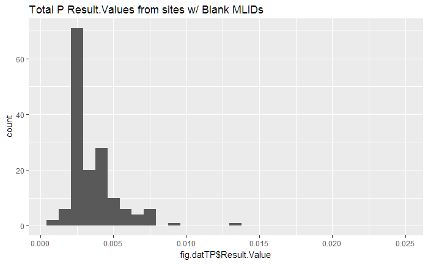

```r
library(ggplot2); library(scales)
fig.datTP <- Blank.TP
fig.datTP$Flag <- ifelse(!is.na(fig.datTP$Result.Code),
                        ifelse(grepl("U",fig.datTP$Result.Code),
                               "U",
                               ifelse(grepl("J", fig.datTP$Result.Code),
                                      "J", NA)))
#
qplot(fig.datTP$Result.Value, main="Total P Result.Values from sites w/ Blank MLIDs ", xlim=c(NA, 0.025))
```

```r
summary(fig.datTP$Result.Value[!is.na(fig.datTP$Flag) & fig.datTP$Flag == "J"])
```

```
   Min. 1st Qu.  Median    Mean 3rd Qu.    Max.
0.00150 0.00180 0.00275 0.00242 0.00287 0.00290
```

```r
summary(fig.datTP$Result.Value[!is.na(fig.datTP$Flag) & fig.datTP$Flag == "U"])
```

```
   Min. 1st Qu.  Median    Mean 3rd Qu.    Max.
0.00080 0.00280 0.00280 0.00273 0.00280 0.00280
```

```r
summary(fig.datTP$Result.Value[is.na(fig.datTP$Flag)])
```

```
   Min. 1st Qu.  Median    Mean 3rd Qu.    Max.
0.00300 0.00372 0.00410 0.00936 0.00552 0.31600
```

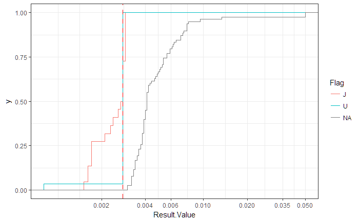

```r
ggplot(data=fig.datTP) + theme_bw() +
        stat_ecdf(aes(x=Result.Value, color=Flag), na.rm=T) +
        scale_x_continuous(trans="log10", oob=squish, limits=c(NA, 0.05),
                           breaks=c(0.002,0.004, 0.006, 0.01, 0.02, 0.035, 0.05)) +
    geom_vline(xintercept=0.0028, lty="99", color="red")
```

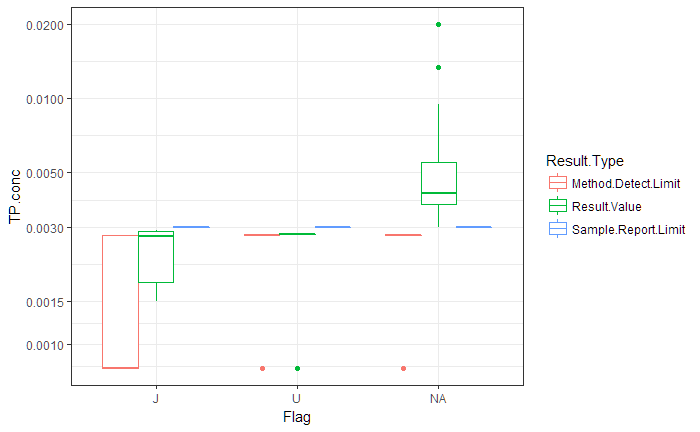

```r
#
library(tidyr);
fig.dat2 <- fig.datTP[,c("Result.Value", "Sample.Report.Limit", "Method.Detect.Limit", "Flag")] %>%
    gather(key, value=TP.conc, -Flag)
names(fig.dat2)[2] <- "Result.Type"
ggplot(data=fig.dat2) + theme_bw() + geom_boxplot(aes(x=Flag, y=TP.conc, col=Result.Type), na.rm=T) +
    scale_y_continuous(limits=c(NA, 0.02), trans="log10", oob=squish, breaks=c(0.001, 0.0015, 0.003, 0.005, 0.01, 0.02))
```